# NLP_HW_p2_Mohammed_Almasry

```python
# Don't uncomment and run this cell unless you are on the google colab
# ! pip install 'nltk==3.4.5'
```

```
     |████████████████████████████████| 1.5MB 7.6MB/s
  Found existing installation: nltk 3.2.5
    Uninstalling nltk-3.2.5:
      Successfully uninstalled nltk-3.2.5
```

```python
# Don't uncomment and run this cell unless you are on the google colab
#from google.colab import drive
#drive.mount('/gdrive')
```

```
Mounted at /gdrive
```

```python
# Don't uncomment and run this cell unless you are on the google colab
#import nltk
#nltk.download('stopwords')
```

```
True
```

```python
import nltk
from nltk import stem
from nltk.corpus import stopwords
import numpy as np
import pandas as pd
import random
import re
import matplotlib.pyplot as plt
import plotly.graph_objects as go
import plotly.express as px
import plotly.figure_factory as ff
import seaborn as sns
import string
from string import punctuation
import os
from wordcloud import WordCloud,STOPWORDS
from sklearn.feature_extraction.text import CountVectorizer
from sklearn.feature_extraction.text import TfidfVectorizer
from sklearn.cluster import KMeans
from nltk.collocations import BigramCollocationFinder
from nltk.metrics import BigramAssocMeasures
from nltk.collocations import TrigramCollocationFinder
from nltk.metrics import TrigramAssocMeasures
from nltk import word_tokenize, sent_tokenize
from nltk.tokenize.treebank import TreebankWordDetokenizer
from nltk.lm import MLE
from nltk.lm.preprocessing import padded_everygram_pipeline
detokenize = TreebankWordDetokenizer().detokenize
from sklearn.model_selection import train_test_split
from sklearn.linear_model import LogisticRegression
from sklearn.svm import LinearSVC
from sklearn.naive_bayes import MultinomialNB
from sklearn.metrics import accuracy_score, classification_report
import tensorflow as tf
from tensorflow.keras.preprocessing.text import Tokenizer
from tensorflow.keras.preprocessing.sequence import pad_sequences
from tensorflow.keras import layers
from tensorflow.keras.losses import SparseCategoricalCrossentropy
from tensorflow.keras.optimizers import Adam
from tensorflow.keras.layers import Dense, Input, GlobalAveragePooling1D, Dropout, SpatialDropout1D
from tensorflow.keras.layers import LSTM,Bidirectional,GlobalMaxPool1D, Embedding
from tensorflow.keras.models import Sequential
from tensorflow.keras.models import load_model
stopwords = set(stopwords.words('english'))
import warnings
warnings.simplefilter('ignore')
```

```python
df = pd.read_csv('Covid_19_tweets_train.csv',encoding="latin1")
df.head()
```

|  | UserName | ScreenName | Location | TweetAt | OriginalTweet | Sentiment |
| --- | --- | --- | --- | --- | --- | --- |
| 0 | 3799 | 48751 | London | 16-03-2020 | @MeNyrbie @Phil_Gahan @Chrisitv https://t.co/i... | Neutral |
| 1 | 3800 | 48752 | UK | 16-03-2020 | advice Talk to your neighbours family to excha... | Positive |
| 2 | 3801 | 48753 | Vagabonds | 16-03-2020 | Coronavirus Australia: Woolworths to give elde... | Positive |
| 3 | 3802 | 48754 | NaN | 16-03-2020 | My food stock is not the only one which is emp... | Positive |
| 4 | 3803 | 48755 | NaN | 16-03-2020 | Me, ready to go at supermarket during the #COV... | Extremely Negative |

```python
df.shape
```

```
(41157, 6)
```

```python
df.info()
```

```
<class 'pandas.core.frame.DataFrame'>
RangeIndex: 41157 entries, 0 to 41156
Data columns (total 6 columns):
UserName         41157 non-null int64
ScreenName       41157 non-null int64
Location         32567 non-null object
TweetAt          41157 non-null object
OriginalTweet    41157 non-null object
Sentiment        41157 non-null object
dtypes: int64(2), object(4)
memory usage: 1.9+ MB
```

```python
df.isnull().count()
```

```
UserName         41157
ScreenName       41157
Location         41157
TweetAt          41157
OriginalTweet    41157
Sentiment        41157
dtype: int64
```

```python
print('Total tweets in this data: {}'.format(df.shape[0]))
print('Total Unique Users in this data: {}'.format(df['UserName'].nunique()))
```

```
Total tweets in this data: 41157
Total Unique Users in this data: 41157
```

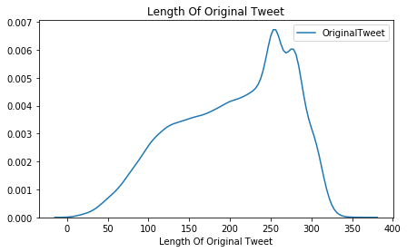

```python
plt.figure(figsize=(7,4))
sns.kdeplot(df["OriginalTweet"].apply(lambda x: len(x)))
plt.title("Length Of Original Tweet")
plt.xlabel("Length Of Original Tweet")
plt.show()
```

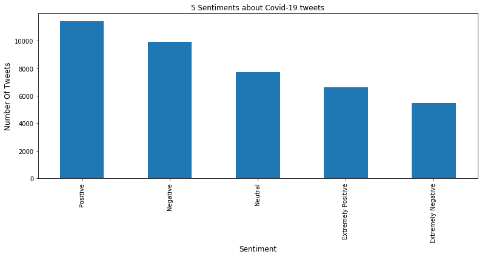

```python
top_all_the_time  = df['Sentiment'].value_counts().sort_values(ascending = False)
fig, ax = plt.subplots(figsize = (13,5))
plt.xlabel("Sentiment", fontsize = 12)
plt.ylabel("Number Of Tweets", fontsize = 12)
top_all_the_time[0:5].plot(kind='bar', title = "5 Sentiments about Covid-19 tweets" , )
```

```python
print("Number Of Unique Locations:",df["Location"].nunique())
```

```
Number Of Unique Locations: 12220
```

# missing values in location column

```python
print("Number of unknown Locations:",df["Location"].isna().sum())
```

```
Number of unknown Locations: 8590
```

```python
def return_missing_values(df):
    print("Percentage of missing values")
    print("============================")

    for var in df.columns:
        if df[var].isna().sum() >0:
            miss = np.round(df[var].isna().sum()/df.shape[0] * 100,3)
            print(var, "has {0}% of missing values".format(miss))
```

```python
return_missing_values(df)
```

```
Percentage of missing values
============================
Location has 20.871% of missing values
```

# Heatmap Representation Of Missing Values

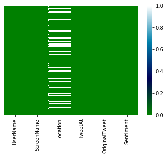

```python
sns.heatmap(df.isnull(), cbar=True, yticklabels=False, cmap='ocean')
```

```python
def clean_Text(text,flag):

    #Make text lowercase
    text = text.lower()

    #remove text in square brackets
    text = re.sub('\[.*?\]', '', text)

    #remove links
    text = re.sub('https?://\S+|www\.\S+', '', text)

    #remove html
    text = re.sub('<.*?>+', '', text)

    #remove punctuation except hashtag mark
    x=punctuation
    y=""
    if flag:
        y=x[0:2]+x[3:13]+x[14:]
    else:
        y=x[0:2]+x[3:]
    text = re.sub('[%s]' % re.escape(y), '', text)

    #remove \n
    text = re.sub('\n', '', text)

    #remove Emoji
    emoji_pattern = re.compile("["
                           u"\U0001F600-\U0001F64F"  # emoticons
                           u"\U0001F300-\U0001F5FF"  # symbols & pictographs
                           u"\U0001F680-\U0001F6FF"  # transport & map symbols
                           u"\U0001F1E0-\U0001F1FF"  # flags (iOS)
                           u"\U00002702-\U000027B0"
                           u"\U000024C2-\U0001F251"
                           "]+", flags=re.UNICODE)


    return emoji_pattern.sub(r'', text)

def remove_Stopword_Lemmatize_Msg(msg):

    # converting messages to lowercase
    msg = msg.lower()

    # removing stopwords
    msg = [word for word in msg.split() if word not in stopwords]

    # using a stemmer
    #stemmer = stem.PorterStemmer()
    #msg = " ".join([stemmer.stem(word) for word in msg])

    # using a Lemmatizer
    # lemmatization is preferred over Stemming because lemmatization does morphological analysis of the words.
    wnl = nltk.WordNetLemmatizer()
    msg =" ".join([wnl.lemmatize(word) for word in msg])

    return msg

def get_Hashtags(text):
    l=re.findall("#\w+",text)
    rl=[]
    for i in l:
        rl.append(i[1:])
    return " ".join(rl)

def unusual_words(text):
    text_vocab = set(w.lower() for w in text if w.isalpha())
    english_vocab = set(w.lower() for w in nltk.corpus.words.words())
    unusual = text_vocab - english_vocab
    return sorted(unusual)

def build_wordcloud(df, title):
    wordcloud = WordCloud(
        background_color='gray',
        stopwords=set(STOPWORDS),
        max_words=50,
        max_font_size=40,
        random_state=666
    ).generate(str(df))

    fig = plt.figure(1, figsize=(14,14))
    plt.axis('off')
    fig.suptitle(title, fontsize=16)
    fig.subplots_adjust(top=2.3)

    plt.imshow(wordcloud)
    plt.show()

def wordcloud(string):
    stop_words=set(STOPWORDS)
    wc = WordCloud(width=800,height=500,mask=None,random_state=21, max_font_size=110,stopwords=stop_words).generate(string)
    fig=plt.figure(figsize=(16,8))
    plt.axis('off')
    plt.imshow(wc)

def ditribution_plot(x,y,name):
    fig = go.Figure([
        go.Bar(x=x, y=y)
    ])

    fig.update_layout(title_text=name)
    fig.show()

def generate_sent(model, num_words, random_seed=42):
    """
    :param model: An ngram language model from `nltk.lm.model`.
    :param num_words: Max no. of words to generate.
    :param random_seed: Seed value for random.
    """
    content = []
    for token in model.generate(num_words, random_seed=random_seed):
        if token == '<s>':
            continue
        if token == '</s>':
            break
        content.append(token)
    return detokenize(content)

def plot_history(history):
    acc = history.history['accuracy']
    val_acc = history.history['val_accuracy']
    loss = history.history['loss']
    val_loss = history.history['val_loss']
    x = range(1, len(acc) + 1)

    plt.figure(figsize=(12, 5))
    plt.subplot(1, 2, 1)
    plt.plot(x, acc, 'b', label='Training acc')
    plt.plot(x, val_acc, 'r', label='Validation acc')
    plt.title('Training and validation accuracy')
    plt.legend()
    plt.subplot(1, 2, 2)
    plt.plot(x, loss, 'b', label='Training loss')
    plt.plot(x, val_loss, 'r', label='Validation loss')
    plt.title('Training and validation loss')
    plt.legend()
```

# Remove null values from Location column

```python
li=list(df["Location"].isna())

known_locations=[]
i=0
for ele in li:
    if not ele :
        known_locations.append(df["Location"][i])
    #else :
    #     null value , unknown location
    #    known_locations.append("Unknown")
    i=i+1
i=0
for ele in known_locations:
    known_locations[i]=remove_Stopword_Lemmatize_Msg(clean_Text(known_locations[i],False))
    i=i+1
```

```python
# A frequency distribution is basically an enhanced Python dictionary where the keys are what’s being counted,
# and the values are the counts.
fdist = nltk.FreqDist(known_locations)
print(fdist.most_common(50))
```

```
[('london', 579), ('united state', 532), ('london england', 527), ('washington dc', 498), ('new york ny', 400), ('', 382), ('united kingdom', 347), ('india', 301), ('los angeles ca', 299), ('usa', 269), ('uk', 265), ('australia', 237), ('canada', 212), ('england united kingdom', 194), ('boston', 184…
```

# Top 25 locations posting about Covid-19 from frequency distribution

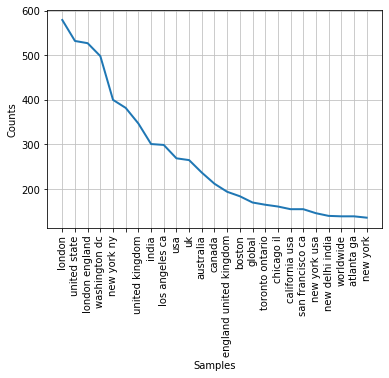

```python
fdist.plot(25)
```

# Top 15 locations posting about Covid-19 from location column

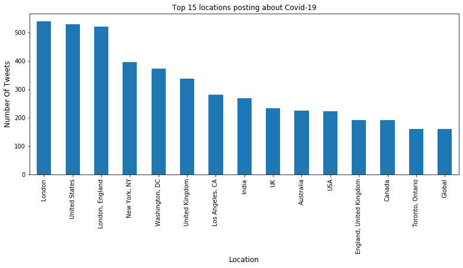

```python
top_all_the_time  = df['Location'].value_counts().sort_values(ascending = False)
fig, ax = plt.subplots(figsize = (13,5))
plt.xlabel("Location", fontsize = 12)
plt.ylabel("Number Of Tweets", fontsize = 12)
top_all_the_time[0:15].plot(kind='bar', title = "Top 15 locations posting about Covid-19", )
```

# 1. Clean the tweets ( make text lowercase, remove text in square brackets,links,html tags,punctuation except hashtag mark,\n and Emoji )

# 2. Remove stopword and lemmatize the tweets using WordNetLemmatizer

# 3. Get hashtags from the tweets

```python
df['OriginalTweet1'] = df['OriginalTweet'].apply(lambda x: remove_Stopword_Lemmatize_Msg(clean_Text(x,False)))
df['Hashtags'] = df['OriginalTweet1'].apply(lambda x: get_Hashtags(x))
```

# Top 13 Hashtags Posting about Covid-19

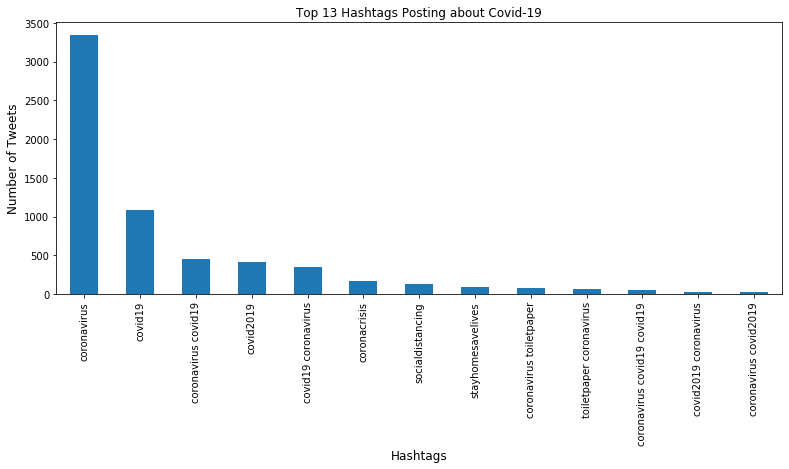

```python
top_all_the_time  = df['Hashtags'].value_counts().sort_values(ascending = False)
fig, ax = plt.subplots(figsize = (13,5))
plt.xlabel("Hashtags", fontsize = 12)
plt.ylabel("Number of Tweets", fontsize = 12)
top_all_the_time[1:14].plot(kind='bar', title = "Top 13 Hashtags Posting about Covid-19", )
```

# Collocations are two or more words that tend to appear frequently together, for example – United States.

## BigramCollocationFinder constructs two frequency distributions:

```python
#Convert tweets column into one string
str_tweets=" ".join(df['OriginalTweet1'].astype('str'))
```

```python
biagram_collocation = BigramCollocationFinder.from_words(str_tweets.split())
biagram_collocation.nbest(BigramAssocMeasures.likelihood_ratio, 15)
```

```
[('grocery', 'store'),
 ('covid', '19'),
 ('toilet', 'paper'),
 ('hand', 'sanitizer'),
 ('panic', 'buying'),
 ('online', 'shopping'),
 ('social', 'distancing'),
 ('oil', 'price'),
 ('#coronavirus', '#covid19'),
 ('#covid19', '#coronavirus'),
 ('supply', 'chain'),
 ('stay', 'home'),
 ('food', 'bank'),
 ('covid19', 'pandemic'),
 ('front', 'line')]
```

# Finding and ranking of trigram collocations

```python
trigram_collocation = TrigramCollocationFinder.from_words(str_tweets.split())
trigram_collocation.nbest(TrigramAssocMeasures.likelihood_ratio, 15)
```

```
[('grocery', 'store', 'worker'),
 ('grocery', 'store', 'employee'),
 ('go', 'grocery', 'store'),
 ('grocery', 'store', 'clerk'),
 ('online', 'grocery', 'store'),
 ('went', 'grocery', 'store'),
 ('going', 'grocery', 'store'),
 ('local', 'grocery', 'store'),
 ('grocery', 'store', 'closure'),
 ('trip', 'grocery', 'store'),
 ('grocery', 'store', 'closed'),
 ('work', 'grocery', 'store'),
 ('grocery', 'store', 'pharmacy'),
 ('grocery', 'store', 'today'),
 ('grocery', 'store', 'shelf')]
```

```python
fdist = nltk.FreqDist(str_tweets.split())
```

# Fifty words least repeated from tweets

```python
dict1 = dict(fdist)
sorted_dict = {}
sorted_keys = sorted(dict1, key=dict1.get)

for w in sorted_keys:
    sorted_dict[w] = dict1[w]

items_cnt=0
for x,y in sorted_dict.items():
    print("(",x,":",y,")\n")
    items_cnt=items_cnt+1
    if items_cnt == 50:
        break
```

```
( menyrbie : 1 )

( philgahan : 1 )

( #confinementgeneral : 1 )

( litteraly : 1 )

( #coronavirusfrance : 1 )

( timdodson : 1 )

( civics : 1 )

( #rebel : 1 )

( preventionwe : 1 )

( #govindia : 1 )

( #manila : 1 )

( #horningsea : 1 )

( adara : 1 )

( eyeonthearctic : 1 )

( 16mar20 : 1 )

( groceriesâ : 1 )

( inficted : 1 )

( guilde : 1 )

( safty : 1 )

( irosponcible : 1 )

```

[output cut: 44 more lines]

```
( #imadethisup : 1 )

( freezable : 1 )

( #peoplearelosingtheirminds : 1 )

( proliferation : 1 )

( #mufcfamily : 1 )

( bobjlowe : 1 )

( misinformed : 1 )

( tinamccauley70 : 1 )
```

# Fifty most frequent words from tweets

```python
print(fdist.most_common(50))
```

```
[('#coronavirus', 15847), ('#covid19', 9225), ('price', 8810), ('store', 8082), ('covid19', 7562), ('supermarket', 7221), ('food', 6902), ('grocery', 6478), ('people', 5525), ('amp', 4953), ('consumer', 4876), ('19', 3687), ('shopping', 3344), ('online', 3325), ('need', 3212), ('time', 3081), ('get'…
```

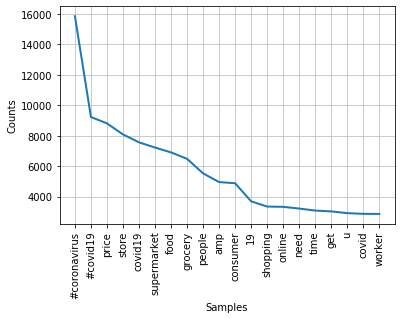

```python
fdist.plot(20)
```

# Let's display some unusual words from tweets

```python
list_unusual_words=unusual_words(str_tweets.split())
```

```python
" ".join(list_unusual_words[0:100])
```

```
'aaa aaaaas aaaand aaaarizona aaancnu aaanews aaannnddd aaanortheast aabutan aacopd aacountygovt aadeshrawal aafp aahealth aahh aaiofficial aaisp aajeevika aajtak aalonzowatt aalto aaltouniversity aamaadmi aamaadmiparty aampe aantal aanthanurdc aaoophth aap aapdelhi aapi aapka aapl aappres aapss aar…
```

```python
location_string = " ".join(pd.Series(known_locations).astype('str'))
text_string = " ".join(df['OriginalTweet'].astype('str'))
text_after_cleaning_string = " ".join(df['OriginalTweet1'].astype('str'))
Sentiment_string = " ".join(df['Sentiment'].astype('str'))
hastage_string = " ".join(df['Hashtags'].astype('str'))
```

# Word Cloud

## word cloud is a data visualization technique used for representing text data in which the size of each word indicates its frequency or importance. Significant textual data points can be highlighted using a word cloud.

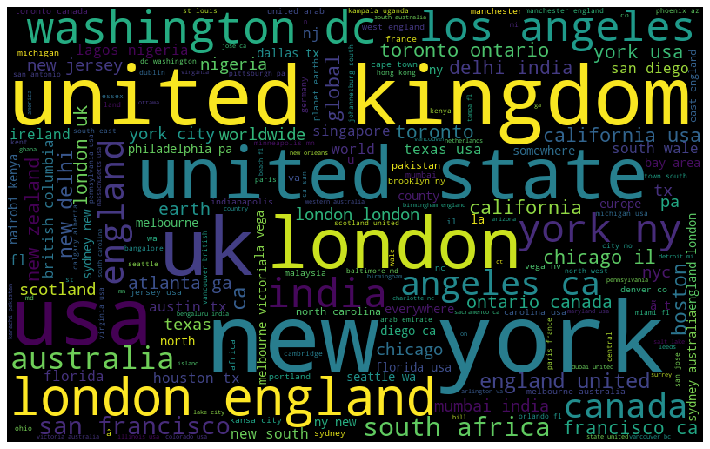

```python
wordcloud(location_string)
```

# Tweets before cleaning and normalization

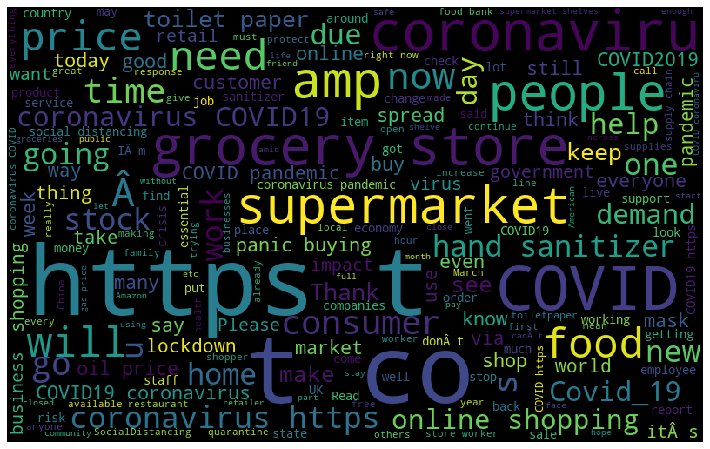

```python
wordcloud(text_string)
```

# Tweets after cleaning and normalization

### We can see that there are no links any more or any stopword in tweets.

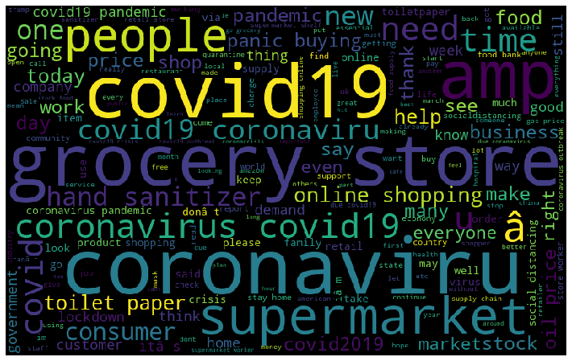

```python
wordcloud(text_after_cleaning_string)
```

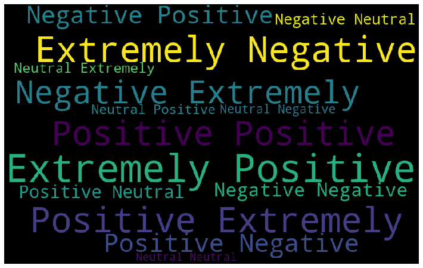

```python
wordcloud(Sentiment_string)
```

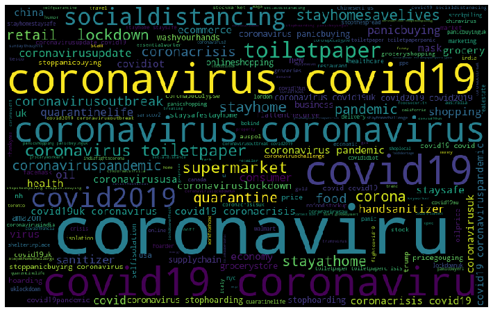

```python
wordcloud(hastage_string)
```

# Clustering

### clusteringis the task of dividing the population or data points into a number of groups such that data points in the same groups are more similar to other data points in the same group than those in other groups. In simple words, the aim is to segregate groups with similar traits and assign them into clusters.

# We use Kmeans clustering algotithm to split data into 2 clusters.

# How does K-Means clustering algorithm work? Explained in 6 Points.

### 1. K points randomly selected as cluster centers(centroids).

### 2. All the nearest points to these K centroids form a cluster.

### 3. Means of all points of various clusters is found.

### 4. These mean points are the new cluster centers or centroids.

### 5. Repeat steps 2 to 4 until the centroids stop moving or changing or stopping criteria is reached like maximum iterations etc.

### 6. Final centroids are cluster centers and all the points nearest to a centroid belong to that cluster.

# We use Tfidf Vectorizer to get the features

```python
tfidf = TfidfVectorizer(min_df=2, max_df=0.5,ngram_range = (1, 2))
features = tfidf.fit_transform(df['OriginalTweet1'].values)
```

```python
features.shape
```

```
(41157, 96034)
```

# Kmeans (2 clusters)

```python
kmeans = KMeans(n_clusters=2, random_state=0)
kmeans.fit(features)
```

```
KMeans(algorithm='auto', copy_x=True, init='k-means++', max_iter=300,
       n_clusters=2, n_init=10, n_jobs=None, precompute_distances='auto',
       random_state=0, tol=0.0001, verbose=0)
```

```python
df['Cluster'] = kmeans.predict(features)
```

```python
df[['OriginalTweet1','Cluster']].sample(15)
```

|  | OriginalTweet1 | Cluster |
| --- | --- | --- |
| 24620 | awesome member public put sign grocery store a... | 0 |
| 10433 | hope help people #coronavirus madness believe ... | 1 |
| 11042 | mean live italy cradle eat supermarket frozen ... | 1 |
| 35611 | newsroom covid19 commissioner reynders repeat ... | 1 |
| 14959 | smart danish store end hand sanitizer shortage... | 1 |
| 22967 | stay safe informed global pandemic #covid19 la... | 1 |
| 24896 | help stop spread shopping store | 0 |
| 35356 | mom amp dad getting worried working grocery st... | 0 |
| 1616 | #covid19s business #consumerimpact europe #mar... | 1 |
| 36264 | stay date center food integrityâs weekly webi... | 1 |
| 2513 | son sneezed grocery store morning people looke... | 0 |
| 9253 | there need panic buy carry normal buy thing ne... | 1 |
| 21410 | #egg price skyrocket result #coronavirus | 1 |
| 35261 | grocery store worker putting life risk go work... | 0 |
| 6035 | action alert time pa family worrying #coronavi... | 1 |

```python
print('Number of samples for class 0: ', len(df[df['Cluster'] == 0]))
print('Number of samples for class 1: ', len(df[df['Cluster'] == 1]))
```

```
Number of samples for class 0:  5417
Number of samples for class 1:  35740
```

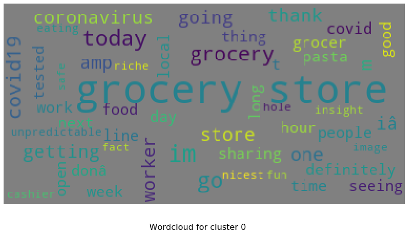

```python
build_wordcloud(df[df['Cluster'] == 0]['OriginalTweet1'], 'Wordcloud for cluster 0')
```

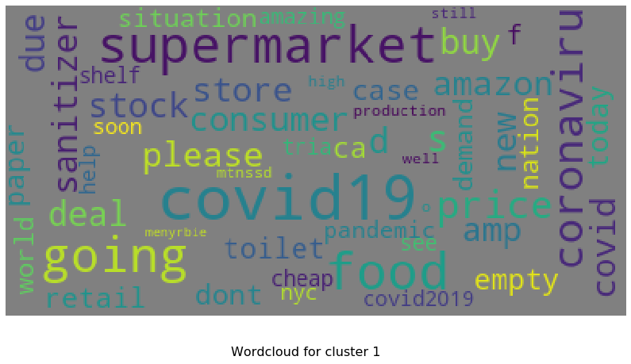

```python
build_wordcloud(df[df['Cluster'] == 1]['OriginalTweet1'], 'Wordcloud for cluster 1')
```

# Kmeans (5 clusters)

# We also use Kmeans clustering algotithm to split data into 5 clusters.

```python
kmeans1 = KMeans(n_clusters=5, random_state=0)
kmeans1.fit(features)
```

```
KMeans(algorithm='auto', copy_x=True, init='k-means++', max_iter=300,
       n_clusters=5, n_init=10, n_jobs=None, precompute_distances='auto',
       random_state=0, tol=0.0001, verbose=0)
```

```python
ans = kmeans1.predict(features)
df['Cluster5'] = ans
```

```python
df[['OriginalTweet1','Cluster5']].sample(15)
```

|  | OriginalTweet1 | Cluster5 |
| --- | --- | --- |
| 2629 | #covid2019 got online shopping 247 | 4 |
| 9483 | âwe togetherâ schoofsfeed lived aid epidemic... | 0 |
| 17008 | im actually going working supermarket crisis i... | 2 |
| 27475 | thank sainsburys managed register elderly pare... | 4 |
| 34625 | whe grocery store practice #socialdistancing c... | 1 |
| 5967 | motherboard two type people online shopper peo... | 4 |
| 11860 | man jeremy vine last time went supermarket loc... | 2 |
| 39868 | 20 year ago stood long line get hottest dance ... | 1 |
| 32453 | â«â belgian supermarket worker dy testing posi... | 2 |
| 17907 | good rt worried far apart supermarket line sur... | 2 |
| 32665 | chinaâs development farm management tech onli... | 0 |
| 39199 | head working hard home week amp finally run ca... | 2 |
| 9272 | woman mkt meat dept customer demand chopped me... | 0 |
| 29572 | anyone looking great recipe diy hand sanitizer... | 3 |
| 35353 | according consumer lab effective disinfectant ... | 0 |

```python
for i in range(5):
    print('Number of samples for class ' + str(i) + ': ', len(df[df['Cluster5'] == i]))
```

```
Number of samples for class 0:  17465
Number of samples for class 1:  5273
Number of samples for class 2:  12262
Number of samples for class 3:  3691
Number of samples for class 4:  2466
```

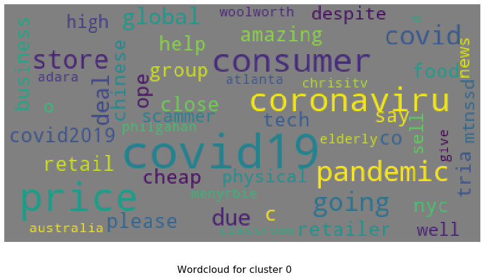

```python
build_wordcloud(df[df['Cluster5'] == 0]['OriginalTweet1'], 'Wordcloud for cluster 0')
```

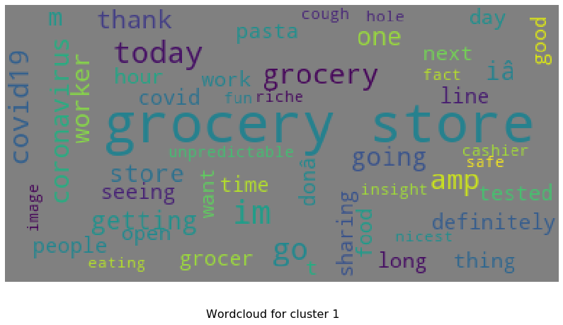

```python
build_wordcloud(df[df['Cluster5'] == 1]['OriginalTweet1'], 'Wordcloud for cluster 1')
```

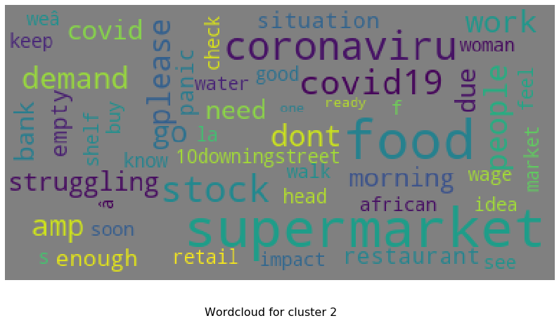

```python
build_wordcloud(df[df['Cluster5'] == 2]['OriginalTweet1'], 'Wordcloud for cluster 2')
```

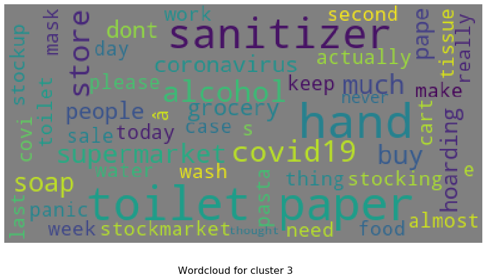

```python
build_wordcloud(df[df['Cluster5'] == 3]['OriginalTweet1'], 'Wordcloud for cluster 3')
```

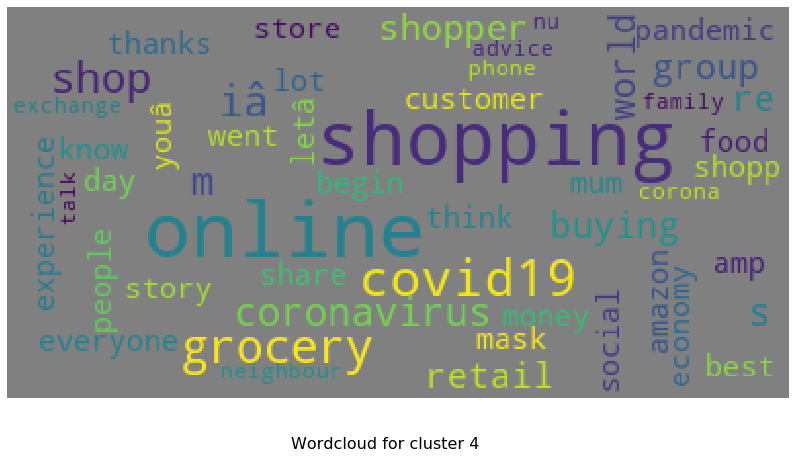

```python
build_wordcloud(df[df['Cluster5'] == 4]['OriginalTweet1'], 'Wordcloud for cluster 4')
```

# Language Models

```python
list_tweets=str_tweets.split()
```

```python
model = MLE(3)
```

```python
len(model.vocab)
```

```
0
```

```python
df['OriginalTweet2'] = df['OriginalTweet'].apply(lambda x: clean_Text(x,True))
```

```python
str_tweets1=" ".join(df['OriginalTweet2'].astype('str'))
```

```python
tokenized_text = [list(map(str.lower, word_tokenize(sent))) for sent in sent_tokenize(str_tweets1)]
```

```python
tokenized_text[3]
```

```
['not',
 'because',
 'im',
 'paranoid',
 'but',
 'because',
 'my',
 'food',
 'stock',
 'is',
 'litteraly',
 'empty',
 '.']
```

```python
train_data, padded_sents = padded_everygram_pipeline(3, tokenized_text)
```

```python
model.fit(train_data, padded_sents)
print(model.vocab)
```

```
<Vocabulary with cutoff=1 unk_label='<UNK>' and 63841 items>
```

```python
print(model.vocab.lookup(tokenized_text[1]))
```

```
('stay', 'calm', 'stay', 'safe', '.')
```

```python
generate_sent(model, 6, random_seed=29)
```

```
'is going to effect the coronavirus'
```

```python
generate_sent(model, 20, random_seed=12)
```

```
'government on other courses in light of the pandemic it is our country is facing tough times social distancing no'
```

```python
generate_sent(model, 20, random_seed=42)
```

```
'now #coronavirus #quarantine #toiletpaper #gas #lng prices and cutting hours whats your number 75k cases'
```

```python
generate_sent(model, 20, random_seed=34)
```

```
'in primarily covid19 stories over the world grapples with a longer lasting recession new research out of a dozen out'
```

# Text Classification - Sentiment Analysis

```python
def clean_Text_1(text,flag=""):

    #Make text lowercase
    text = text.lower()

    #remove text in square brackets
    text = re.sub('\[.*?\]', '', text)

    #remove links
    text = re.sub('https?://\S+|www\.\S+', '', text)

    #remove html
    text = re.sub('<.*?>+', '', text)

    #remove the hashtags
    if flag == "removeHashtags" :
      text = re.sub('#\w*[a-zA-Z]\w*','',text)

    #split Hashtags
    if flag == "splitHashtags":
      text = re.sub('[_#]', ' ', text)

    #remove punctuation
    x=punctuation
    y=x[0:2]+x[3:26]+x[27:]
    text = re.sub('[%s]' % re.escape(y), '', text)

    #remove \n
    text = re.sub('\n', '', text)

    text = text.strip()

    #Keep these characters
    text = re.sub("[^A-Za-z0-9#@+_ ]","",text)

    #remove Emoji
    emoji_pattern = re.compile("["
                           u"\U0001F600-\U0001F64F"  # emoticons
                           u"\U0001F300-\U0001F5FF"  # symbols & pictographs
                           u"\U0001F680-\U0001F6FF"  # transport & map symbols
                           u"\U0001F1E0-\U0001F1FF"  # flags (iOS)
                           u"\U00002702-\U000027B0"
                           u"\U000024C2-\U0001F251"
                           "]+", flags=re.UNICODE)


    return emoji_pattern.sub(r'', text)

def cvt5CTo2C(x):
    if x == 'Extremely Negative' or x == 'Negative' :
        return 0
    if x == 'Positive' or x == 'Extremely Positive' :
        return 1
    return 2

def cvt5CToNumerical5C(x):
    if x == 'Extremely Negative' :
        return 0
    if x == 'Negative' :
        return 1
    if x == 'Positive' :
        return 2
    if x == 'Extremely Positive' :
        return 3
    return 4

def train_evaluate_model(Model_Name, Model, X_train, X_test, y_train, y_test):
    print(f'Start. {Model_Name.upper()}......')
    Model.fit(X_train, y_train)
    y_pred = Model.predict(X_test)
    y_train_pred = Model.predict(X_train)
    print(f'Accuracy On Testing Data --> {Model_Name.upper()}: \t\t{accuracy_score(y_test, y_pred) * 100:.2f}%')
    print(f'Accuracy On Training Data --> {Model_Name.upper()}: \t\t{accuracy_score(y_train, y_train_pred) * 100:.2f}%')
    print(classification_report(y_test, y_pred))
    print(f'End. {Model_Name.upper()}')
    print('======================================================')
    return y_pred

def plot_history(history):
    acc = history.history['accuracy']
    val_acc = history.history['val_accuracy']
    loss = history.history['loss']
    val_loss = history.history['val_loss']
    x = range(1, len(acc) + 1)

    plt.figure(figsize=(12, 5))
    plt.subplot(1, 2, 1)
    plt.plot(x, acc, 'b', label='Training acc')
    plt.plot(x, val_acc, 'r', label='Validation acc')
    plt.title('Training and validation accuracy')
    plt.legend()
    plt.subplot(1, 2, 2)
    plt.plot(x, loss, 'b', label='Training loss')
    plt.plot(x, val_loss, 'r', label='Validation loss')
    plt.title('Training and validation loss')
    plt.legend()

def plot_loss_evaluation(r):
    plt.figure(figsize=(12, 8))

    plt.subplot(2, 2, 1)
    plt.plot(r.history['loss'], label='loss')
    plt.plot(r.history['val_loss'], label='val_loss')
    plt.legend()

    plt.subplot(2, 2, 2)
    plt.plot(r.history['accuracy'], label='accuracy')
    plt.plot(r.history['val_accuracy'], label='val_acc')
    plt.legend()

def evaluate(model, X_train, X_test, y_train, y_test):

    y_pred_train = np.round(model.predict(X_train))
    y_pred_test = np.round(model.predict(X_test))

    print("=============Training Data===============")
    print(confusion_matrix(y_train, y_pred_train))
    print(classification_report(y_train, y_pred_train))
    print(f"Accuracy score: {accuracy_score(y_train, y_pred_train) * 100:.2f}%")

    print("=============Testing Data===============")
    print(confusion_matrix(y_test, y_pred_test))
    print(classification_report(y_test, y_pred_test))
    print(f"Accuracy score: {accuracy_score(y_test, y_pred_test) * 100:.2f}%")
```

```python
df['OriginalTweet_with_hashtags'] = df['OriginalTweet'].apply(lambda x: clean_Text_1(x))
df['OriginalTweet_with_split_hashtags'] = df['OriginalTweet'].apply(lambda x: clean_Text_1(x,"splitHashtags"))
df['OriginalTweet_without_hashtags'] = df['OriginalTweet'].apply(lambda x: clean_Text_1(x,"removeHashtags"))
df['Sentiment2'] = df['Sentiment'].apply(lambda x: cvt5CTo2C(x))
df['Sentiment5'] = df['Sentiment'].apply(lambda x: cvt5CToNumerical5C(x))
str_tweets_with_hashtags=" ".join(df['OriginalTweet_with_hashtags'].astype('str'))
str_tweets_with_split_hashtags=" ".join(df['OriginalTweet_with_split_hashtags'].astype('str'))
str_tweets_without_hashtags=" ".join(df['OriginalTweet_without_hashtags'].astype('str'))
```

```python
df.head(5)
```

|  | UserName | ScreenName | Location | TweetAt | OriginalTweet | Sentiment | OriginalTweet1 | Hashtags | Cluster | Cluster5 | OriginalTweet2 | OriginalTweet_with_hashtags | OriginalTweet_with_split_hashtags | OriginalTweet_without_hashtags | Sentiment2 | Sentiment5 |
| --- | --- | --- | --- | --- | --- | --- | --- | --- | --- | --- | --- | --- | --- | --- | --- | --- |
| 0 | 3799 | 48751 | London | 16-03-2020 | @MeNyrbie @Phil_Gahan @Chrisitv https://t.co/i... | Neutral | menyrbie philgahan chrisitv |  | 1 | 0 | menyrbie philgahan chrisitv and and | menyrbie phil_gahan chrisitv and and | menyrbie phil gahan chrisitv and and | menyrbie phil_gahan chrisitv and and | 2 | 4 |
| 1 | 3800 | 48752 | UK | 16-03-2020 | advice Talk to your neighbours family to excha... | Positive | advice talk neighbour family exchange phone nu... |  | 1 | 4 | advice talk to your neighbours family to excha... | advice talk to your neighbours family to excha... | advice talk to your neighbours family to excha... | advice talk to your neighbours family to excha... | 1 | 2 |
| 2 | 3801 | 48753 | Vagabonds | 16-03-2020 | Coronavirus Australia: Woolworths to give elde... | Positive | coronavirus australia woolworth give elderly d... |  | 1 | 0 | coronavirus australia woolworths to give elder... | coronavirus australia woolworths to give elder... | coronavirus australia woolworths to give elder... | coronavirus australia woolworths to give elder... | 1 | 2 |
| 3 | 3802 | 48754 | NaN | 16-03-2020 | My food stock is not the only one which is emp... | Positive | food stock one empty please dont panic enough ... | covid19france covid19 covid19 coronavirus conf... | 1 | 2 | my food stock is not the only one which is emp... | my food stock is not the only one which is emp... | my food stock is not the only one which is emp... | my food stock is not the only one which is emp... | 1 | 2 |
| 4 | 3803 | 48755 | NaN | 16-03-2020 | Me, ready to go at supermarket during the #COV... | Extremely Negative | ready go supermarket #covid19 outbreak im para... | covid19 coronavirus coronavirusfrance restezch... | 1 | 2 | me ready to go at supermarket during the #covi... | me ready to go at supermarket during the #covi... | me ready to go at supermarket during the covi... | me ready to go at supermarket during the outb... | 0 | 0 |

```python
df_binary_sentiment = df[ df['Sentiment2'] != 2 ]
```

```python
df_binary_sentiment.head(5)
```

|  | UserName | ScreenName | Location | TweetAt | OriginalTweet | Sentiment | OriginalTweet1 | Hashtags | Cluster | Cluster5 | OriginalTweet2 | OriginalTweet_with_hashtags | OriginalTweet_with_split_hashtags | OriginalTweet_without_hashtags | Sentiment2 | Sentiment5 |
| --- | --- | --- | --- | --- | --- | --- | --- | --- | --- | --- | --- | --- | --- | --- | --- | --- |
| 1 | 3800 | 48752 | UK | 16-03-2020 | advice Talk to your neighbours family to excha... | Positive | advice talk neighbour family exchange phone nu... |  | 1 | 4 | advice talk to your neighbours family to excha... | advice talk to your neighbours family to excha... | advice talk to your neighbours family to excha... | advice talk to your neighbours family to excha... | 1 | 2 |
| 2 | 3801 | 48753 | Vagabonds | 16-03-2020 | Coronavirus Australia: Woolworths to give elde... | Positive | coronavirus australia woolworth give elderly d... |  | 1 | 0 | coronavirus australia woolworths to give elder... | coronavirus australia woolworths to give elder... | coronavirus australia woolworths to give elder... | coronavirus australia woolworths to give elder... | 1 | 2 |
| 3 | 3802 | 48754 | NaN | 16-03-2020 | My food stock is not the only one which is emp... | Positive | food stock one empty please dont panic enough ... | covid19france covid19 covid19 coronavirus conf... | 1 | 2 | my food stock is not the only one which is emp... | my food stock is not the only one which is emp... | my food stock is not the only one which is emp... | my food stock is not the only one which is emp... | 1 | 2 |
| 4 | 3803 | 48755 | NaN | 16-03-2020 | Me, ready to go at supermarket during the #COV... | Extremely Negative | ready go supermarket #covid19 outbreak im para... | covid19 coronavirus coronavirusfrance restezch... | 1 | 2 | me ready to go at supermarket during the #covi... | me ready to go at supermarket during the #covi... | me ready to go at supermarket during the covi... | me ready to go at supermarket during the outb... | 0 | 0 |
| 5 | 3804 | 48756 | ÜT: 36.319708,-82.363649 | 16-03-2020 | As news of the regions first confirmed COVID... | Positive | news regionâs first confirmed covid19 case ca... |  | 1 | 3 | as news of the regionâs first confirmed covid... | as news of the regions first confirmed covid19... | as news of the regions first confirmed covid19... | as news of the regions first confirmed covid19... | 1 | 2 |

# Split Data To Be Used In Binary Text Classification (Postive And Negative Classes)

- split operation on tweets with hashtags

```python
train_x2_with_hashtags, test_x2_with_hashtags, train_y2_with_hashtags, test_y2_with_hashtags = train_test_split(df_binary_sentiment['OriginalTweet_with_hashtags'], df_binary_sentiment['Sentiment2'],test_size = 0.2,random_state=1000)
```

- split operation on tweets with split-hashtags

```python
train_x2_with_split_hashtags, test_x2_with_split_hashtags, train_y2_with_split_hashtags, test_y2_with_split_hashtags = train_test_split(df_binary_sentiment['OriginalTweet_with_split_hashtags'], df_binary_sentiment['Sentiment2'],test_size = 0.2,random_state=1000)
```

- split operation on tweets without hashtags

```python
train_x2_without_hashtags, test_x2_without_hashtags, train_y2_without_hashtags, test_y2_without_hashtags = train_test_split(df_binary_sentiment['OriginalTweet_without_hashtags'], df_binary_sentiment['Sentiment2'],test_size = 0.2,random_state=1000)
```

#### These Information are the same on tweets with hashtags and tweets with split hashtags and tweets without hashtags

```python
print("train_x2 shape : ",train_x2_with_hashtags.shape)
print("test_x2 shape : ",  test_x2_with_hashtags.shape)
print("train_y2 shape : ", train_y2_with_hashtags.shape)
print("test_y2 shape : ", test_y2_with_hashtags.shape)
```

```
train_x2 shape :  (26755,)
test_x2 shape :  (6689,)
train_y2 shape :  (26755,)
test_y2 shape :  (6689,)
```

```python
print("\ntrain:")
print(train_x2_with_hashtags.head())
print("\ntest:")
print(test_x2_with_hashtags.head())
print("\ntrain:")
print(train_y2_with_hashtags.head())
print("\ntest:")
print(test_y2_with_hashtags.head())
```

```
train:
2605     i cant even imagine working at a grocery store...
24813    realdonaldtrump just got off the phone with a ...
10657    this is very good news for nhs staff tesco an ...
34853    seen a guy in supermarket today remove his cov...
23954    lidlus addresses #coronavirus measures expands...
Name: OriginalTweet_with_hashtags, dtype: object

test:
520      shame on all of you who are #hoarding this rea...
9712     then why did he invoke he calls a war it autho...
40032    stock prices of life insurance companies which...
3060     im not saying its your faultbut yall did ask f...
1478     i just want a covid19 online shopping sale   f...
Name: OriginalTweet_with_hashtags, dtype: object

train:
2605     0
24813    1
10657    1
34853    0
23954    1
Name: Sentiment2, dtype: int64

test:
520      0
9712     0
40032    1
3060     0
1478     0
Name: Sentiment2, dtype: int64
```

```python
print("\ntrain:")
print(train_x2_with_split_hashtags.head())
print("\ntest:")
print(test_x2_with_split_hashtags.head())
print("\ntrain:")
print(train_y2_with_split_hashtags.head())
print("\ntest:")
print(test_y2_with_split_hashtags.head())
```

```
train:
2605     i cant even imagine working at a grocery store...
24813    realdonaldtrump just got off the phone with a ...
10657    this is very good news for nhs staff tesco an ...
34853    seen a guy in supermarket today remove his cov...
23954    lidlus addresses  coronavirus measures expands...
Name: OriginalTweet_with_split_hashtags, dtype: object

test:
520      shame on all of you who are  hoarding this rea...
9712     then why did he invoke he calls a war it autho...
40032    stock prices of life insurance companies which...
3060     im not saying its your faultbut yall did ask f...
1478     i just want a covid19 online shopping sale   f...
Name: OriginalTweet_with_split_hashtags, dtype: object

train:
2605     0
24813    1
10657    1
34853    0
23954    1
Name: Sentiment2, dtype: int64

test:
520      0
9712     0
40032    1
3060     0
1478     0
Name: Sentiment2, dtype: int64
```

```python
print("\ntrain:")
print(train_x2_without_hashtags.head())
print("\ntest:")
print(test_x2_without_hashtags.head())
print("\ntrain:")
print(train_y2_without_hashtags.head())
print("\ntest:")
print(test_y2_without_hashtags.head())
```

```
train:
2605     i cant even imagine working at a grocery store...
24813    realdonaldtrump just got off the phone with a ...
10657    this is very good news for nhs staff tesco an ...
34853    seen a guy in supermarket today remove his cov...
23954    lidlus addresses  measures expands hiring efforts
Name: OriginalTweet_without_hashtags, dtype: object

test:
520      shame on all of you who are  this really hurts...
9712     then why did he invoke he calls a war it autho...
40032    stock prices of life insurance companies which...
3060     im not saying its your faultbut yall did ask f...
1478     i just want a covid19 online shopping sale   f...
Name: OriginalTweet_without_hashtags, dtype: object

train:
2605     0
24813    1
10657    1
34853    0
23954    1
Name: Sentiment2, dtype: int64

test:
520      0
9712     0
40032    1
3060     0
1478     0
Name: Sentiment2, dtype: int64
```

# Split Data To Be Used In MultiClass Text Classification

- split operation on tweets with hashtags

```python
train_x5_with_hashtags, test_x5_with_hashtags, train_y5_with_hashtags, test_y5_with_hashtags = train_test_split(df['OriginalTweet_with_hashtags'], df['Sentiment5'],test_size = 0.2,random_state=1000)
```

- split operation on tweets with split-hashtags

```python
train_x5_with_split_hashtags, test_x5_with_split_hashtags, train_y5_with_split_hashtags, test_y5_with_split_hashtags = train_test_split(df['OriginalTweet_with_split_hashtags'], df['Sentiment5'],test_size = 0.2,random_state=1000)
```

- split operation on tweets without hashtags

```python
train_x5_without_hashtags, test_x5_without_hashtags, train_y5_without_hashtags, test_y5_without_hashtags = train_test_split(df['OriginalTweet_without_hashtags'], df['Sentiment5'],test_size = 0.2,random_state=1000)
```

#### These Information are the same on tweets with hashtags and tweets with split hashtags and tweets without hashtags

```python
print("train_x5 shape : ",train_x5_with_hashtags.shape)
print("test_x5 shape : ",  test_x5_with_hashtags.shape)
print("train_y5 shape : ", train_y5_with_hashtags.shape)
print("test_y5 shape : ", test_y5_with_hashtags.shape)
```

```
train_x5 shape :  (32925,)
test_x5 shape :  (8232,)
train_y5 shape :  (32925,)
test_y5 shape :  (8232,)
```

```python
print("\ntrain:")
print(train_x5_with_hashtags.head())
print("\ntest:")
print(test_x5_with_hashtags.head())
print("\ntrain:")
print(train_y5_with_hashtags.head())
print("\ntest:")
print(test_y5_with_hashtags.head())
```

```
train:
9825     if you are a clearing supermarket shelves b go...
9398     liz_wheeler not happy about it but we have bas...
22002    interesting the subsaharan story is incomplete...
597      panicbuying in reaction to coronavirus has mea...
6820     petenator39 hogotheforsaken faizashaheen rebel...
Name: OriginalTweet_with_hashtags, dtype: object

test:
2646     industries facing a slump consumer demand down...
10757    when people who said you dont want to end up s...
11975    bbc news  coronavirus nurses despair as panicb...
4709     we encourage all residents to practice social ...
1132     grocery store apologizes for price hike amid t...
Name: OriginalTweet_with_hashtags, dtype: object

train:
9825     1
9398     1
22002    2
597      0
6820     2
Name: Sentiment5, dtype: int64

test:
2646     0
10757    2
11975    1
4709     3
1132     2
Name: Sentiment5, dtype: int64
```

```python
print("\ntrain:")
print(train_x5_with_split_hashtags.head())
print("\ntest:")
print(test_x5_with_split_hashtags.head())
print("\ntrain:")
print(train_y5_with_split_hashtags.head())
print("\ntest:")
print(test_y5_with_split_hashtags.head())
```

```
train:
9825     if you are a clearing supermarket shelves b go...
9398     liz wheeler not happy about it but we have bas...
22002    interesting the subsaharan story is incomplete...
597      panicbuying in reaction to coronavirus has mea...
6820     petenator39 hogotheforsaken faizashaheen rebel...
Name: OriginalTweet_with_split_hashtags, dtype: object

test:
2646     industries facing a slump consumer demand down...
10757    when people who said you dont want to end up s...
11975    bbc news  coronavirus nurses despair as panicb...
4709     we encourage all residents to practice social ...
1132     grocery store apologizes for price hike amid t...
Name: OriginalTweet_with_split_hashtags, dtype: object

train:
9825     1
9398     1
22002    2
597      0
6820     2
Name: Sentiment5, dtype: int64

test:
2646     0
10757    2
11975    1
4709     3
1132     2
Name: Sentiment5, dtype: int64
```

```python
print("\ntrain:")
print(train_x5_without_hashtags.head())
print("\ntest:")
print(test_x5_without_hashtags.head())
print("\ntrain:")
print(train_y5_without_hashtags.head())
print("\ntest:")
print(test_y5_without_hashtags.head())
```

```
train:
9825     if you are a clearing supermarket shelves b go...
9398     liz_wheeler not happy about it but we have bas...
22002    interesting the subsaharan story is incomplete...
597      panicbuying in reaction to coronavirus has mea...
6820     petenator39 hogotheforsaken faizashaheen rebel...
Name: OriginalTweet_without_hashtags, dtype: object

test:
2646     industries facing a slump consumer demand down...
10757    when people who said you dont want to end up s...
11975    bbc news  coronavirus nurses despair as panicb...
4709     we encourage all residents to practice social ...
1132     grocery store apologizes for price hike amid t...
Name: OriginalTweet_without_hashtags, dtype: object

train:
9825     1
9398     1
22002    2
597      0
6820     2
Name: Sentiment5, dtype: int64

test:
2646     0
10757    2
11975    1
4709     3
1132     2
Name: Sentiment5, dtype: int64
```

### Logistic Regression && Naive Bayes && Support Vector Machine using Bag-Of-Word Method on Tweets (2 classes)

```python
def ML_Classifiers_using_bag_of_word(train_x,train_y,test_x,test_y):
  vectorizer = CountVectorizer()
  vectorizer.fit(train_x)
  X_train = vectorizer.transform(train_x)
  X_test  = vectorizer.transform(test_x)
  print(f'X_train shape: {X_train.shape}, train_y shape: {train_y.shape}')
  print(f'X_test shape: {X_test.shape}, test_y shape: {test_y.shape}')

  LR_model_1 = LogisticRegression()
  NB_model_1 = MultinomialNB()
  SVM_model_1 = LinearSVC()
  LR_y_pred_using_bag_of_word = train_evaluate_model('Logistic Regression', LR_model_1, X_train, X_test, train_y, test_y)
  nb_y_pred_using_bag_of_word = train_evaluate_model('Naive Bayes', NB_model_1, X_train, X_test, train_y, test_y)
  svm_y_pred_using_bag_of_word = train_evaluate_model('Support Vector Machine', SVM_model_1, X_train, X_test, train_y, test_y)
```

#### Logistic Regression && Naive Bayes && Support Vector Machine using Bag-Of-Word Method on tweets with hashtags

```python
ML_Classifiers_using_bag_of_word(train_x2_with_hashtags,train_y2_with_hashtags,test_x2_with_hashtags,test_y2_with_hashtags)
```

```
X_train shape: (26755, 50919), train_y shape: (26755,)
X_test shape: (6689, 50919), test_y shape: (6689,)
Start. LOGISTIC REGRESSION......
Accuracy On Testing Data --> LOGISTIC REGRESSION: 		87.52%
Accuracy On Training Data --> LOGISTIC REGRESSION: 		98.24%
              precision    recall  f1-score   support

           0       0.87      0.85      0.86      3042
           1       0.88      0.89      0.89      3647

    accuracy                           0.88      6689
   macro avg       0.87      0.87      0.87      6689
weighted avg       0.88      0.88      0.88      6689

End. LOGISTIC REGRESSION
======================================================
Start. NAIVE BAYES......
Accuracy On Testing Data --> NAIVE BAYES: 		79.01%
Accuracy On Training Data --> NAIVE BAYES: 		90.18%
              precision    recall  f1-score   support

           0       0.78      0.76      0.77      3042
           1       0.80      0.82      0.81      3647

    accuracy                           0.79      6689
   macro avg       0.79      0.79      0.79      6689
weighted avg       0.79      0.79      0.79      6689

End. NAIVE BAYES
======================================================
Start. SUPPORT VECTOR MACHINE......
Accuracy On Testing Data --> SUPPORT VECTOR MACHINE: 		86.38%
Accuracy On Training Data --> SUPPORT VECTOR MACHINE: 		99.90%
              precision    recall  f1-score   support

           0       0.86      0.84      0.85      3042
           1       0.87      0.88      0.88      3647

    accuracy                           0.86      6689
   macro avg       0.86      0.86      0.86      6689
weighted avg       0.86      0.86      0.86      6689

End. SUPPORT VECTOR MACHINE
======================================================
```

#### Logistic Regression && Naive Bayes && Support Vector Machine using Bag-Of-Word Method on tweets with split hashtags

```python
ML_Classifiers_using_bag_of_word(train_x2_with_split_hashtags , train_y2_with_split_hashtags, test_x2_with_split_hashtags, test_y2_with_split_hashtags )
```

```
X_train shape: (26755, 50731), train_y shape: (26755,)
X_test shape: (6689, 50731), test_y shape: (6689,)
Start. LOGISTIC REGRESSION......
Accuracy On Testing Data --> LOGISTIC REGRESSION: 		87.47%
Accuracy On Training Data --> LOGISTIC REGRESSION: 		98.22%
              precision    recall  f1-score   support

           0       0.87      0.86      0.86      3042
           1       0.88      0.89      0.89      3647

    accuracy                           0.87      6689
   macro avg       0.87      0.87      0.87      6689
weighted avg       0.87      0.87      0.87      6689

End. LOGISTIC REGRESSION
======================================================
Start. NAIVE BAYES......
Accuracy On Testing Data --> NAIVE BAYES: 		78.85%
Accuracy On Training Data --> NAIVE BAYES: 		90.14%
              precision    recall  f1-score   support

           0       0.77      0.75      0.76      3042
           1       0.80      0.82      0.81      3647

    accuracy                           0.79      6689
   macro avg       0.79      0.79      0.79      6689
weighted avg       0.79      0.79      0.79      6689

End. NAIVE BAYES
======================================================
Start. SUPPORT VECTOR MACHINE......
Accuracy On Testing Data --> SUPPORT VECTOR MACHINE: 		86.28%
Accuracy On Training Data --> SUPPORT VECTOR MACHINE: 		99.90%
              precision    recall  f1-score   support

           0       0.85      0.84      0.85      3042
           1       0.87      0.88      0.87      3647

    accuracy                           0.86      6689
   macro avg       0.86      0.86      0.86      6689
weighted avg       0.86      0.86      0.86      6689

End. SUPPORT VECTOR MACHINE
======================================================
```

#### Logistic Regression && Naive Bayes && Support Vector Machine using Bag-Of-Word Method on tweets without hashtags

```python
ML_Classifiers_using_bag_of_word(train_x2_without_hashtags,train_y2_without_hashtags,test_x2_without_hashtags,test_y2_without_hashtags)
```

```
X_train shape: (26755, 43182), train_y shape: (26755,)
X_test shape: (6689, 43182), test_y shape: (6689,)
Start. LOGISTIC REGRESSION......
Accuracy On Testing Data --> LOGISTIC REGRESSION: 		88.26%
Accuracy On Training Data --> LOGISTIC REGRESSION: 		98.01%
              precision    recall  f1-score   support

           0       0.87      0.87      0.87      3042
           1       0.89      0.90      0.89      3647

    accuracy                           0.88      6689
   macro avg       0.88      0.88      0.88      6689
weighted avg       0.88      0.88      0.88      6689

End. LOGISTIC REGRESSION
======================================================
Start. NAIVE BAYES......
Accuracy On Testing Data --> NAIVE BAYES: 		79.80%
Accuracy On Training Data --> NAIVE BAYES: 		90.11%
              precision    recall  f1-score   support

           0       0.79      0.76      0.77      3042
           1       0.81      0.83      0.82      3647

    accuracy                           0.80      6689
   macro avg       0.80      0.80      0.80      6689
weighted avg       0.80      0.80      0.80      6689

End. NAIVE BAYES
======================================================
Start. SUPPORT VECTOR MACHINE......
Accuracy On Testing Data --> SUPPORT VECTOR MACHINE: 		87.73%
Accuracy On Training Data --> SUPPORT VECTOR MACHINE: 		99.83%
              precision    recall  f1-score   support

           0       0.87      0.86      0.86      3042
           1       0.89      0.89      0.89      3647

    accuracy                           0.88      6689
   macro avg       0.88      0.88      0.88      6689
weighted avg       0.88      0.88      0.88      6689

End. SUPPORT VECTOR MACHINE
======================================================
```

### Logistic Regression && Naive Bayes && Support Vector Machine using Tf-Idf Method on Tweets (2 classes)

```python
def ML_Classifiers_using_tf_idf(train_x,train_y,test_x,test_y):
  vectorizer1 = TfidfVectorizer(max_df=0.5,min_df=2)
  X_train_vect = vectorizer1.fit_transform(train_x)
  X_test_vect  = vectorizer1.transform(test_x)
  print(f'X_train shape: {X_train_vect.shape}, train_y shape: {train_y.shape}')
  print(f'X_test shape: {X_test_vect.shape}, test_y shape: {test_y.shape}')
  LR_model_2 = LogisticRegression()
  NB_model_2 = MultinomialNB()
  SVM_model_2 = LinearSVC()
  LR_y_pred_using_using_tf_idf = train_evaluate_model('Logistic Regression', LR_model_2, X_train_vect, X_test_vect, train_y, test_y)
  nb_y_pred_pred_using_tf_idf = train_evaluate_model('Naive Bayes', NB_model_2, X_train_vect, X_test_vect, train_y, test_y)
  svm_y_pred_using_tf_idf = train_evaluate_model('Support Vector Machine', SVM_model_2, X_train_vect, X_test_vect, train_y, test_y)
```

#### Logistic Regression && Naive Bayes && Support Vector Machine using Tf-Idf Method on tweets with hashtags

```python
ML_Classifiers_using_tf_idf(train_x2_with_hashtags,train_y2_with_hashtags,test_x2_with_hashtags,test_y2_with_hashtags)
```

```
X_train shape: (26755, 18171), train_y shape: (26755,)
X_test shape: (6689, 18171), test_y shape: (6689,)
Start. LOGISTIC REGRESSION......
Accuracy On Testing Data --> LOGISTIC REGRESSION: 		84.86%
Accuracy On Training Data --> LOGISTIC REGRESSION: 		91.25%
              precision    recall  f1-score   support

           0       0.85      0.81      0.83      3042
           1       0.85      0.88      0.86      3647

    accuracy                           0.85      6689
   macro avg       0.85      0.85      0.85      6689
weighted avg       0.85      0.85      0.85      6689

End. LOGISTIC REGRESSION
======================================================
Start. NAIVE BAYES......
Accuracy On Testing Data --> NAIVE BAYES: 		78.71%
Accuracy On Training Data --> NAIVE BAYES: 		86.21%
              precision    recall  f1-score   support

           0       0.82      0.69      0.75      3042
           1       0.77      0.87      0.82      3647

    accuracy                           0.79      6689
   macro avg       0.79      0.78      0.78      6689
weighted avg       0.79      0.79      0.78      6689

End. NAIVE BAYES
======================================================
Start. SUPPORT VECTOR MACHINE......
Accuracy On Testing Data --> SUPPORT VECTOR MACHINE: 		87.38%
Accuracy On Training Data --> SUPPORT VECTOR MACHINE: 		97.50%
              precision    recall  f1-score   support

           0       0.87      0.85      0.86      3042
           1       0.88      0.89      0.88      3647

    accuracy                           0.87      6689
   macro avg       0.87      0.87      0.87      6689
weighted avg       0.87      0.87      0.87      6689

End. SUPPORT VECTOR MACHINE
======================================================
```

#### Logistic Regression && Naive Bayes && Support Vector Machine using Tf-Idf Method on tweets with split hashtags

```python
ML_Classifiers_using_tf_idf(train_x2_with_split_hashtags , train_y2_with_split_hashtags, test_x2_with_split_hashtags, test_y2_with_split_hashtags )
```

```
X_train shape: (26755, 18272), train_y shape: (26755,)
X_test shape: (6689, 18272), test_y shape: (6689,)
Start. LOGISTIC REGRESSION......
Accuracy On Testing Data --> LOGISTIC REGRESSION: 		84.83%
Accuracy On Training Data --> LOGISTIC REGRESSION: 		91.28%
              precision    recall  f1-score   support

           0       0.85      0.82      0.83      3042
           1       0.85      0.88      0.86      3647

    accuracy                           0.85      6689
   macro avg       0.85      0.85      0.85      6689
weighted avg       0.85      0.85      0.85      6689

End. LOGISTIC REGRESSION
======================================================
Start. NAIVE BAYES......
Accuracy On Testing Data --> NAIVE BAYES: 		78.73%
Accuracy On Training Data --> NAIVE BAYES: 		86.24%
              precision    recall  f1-score   support

           0       0.82      0.68      0.75      3042
           1       0.77      0.87      0.82      3647

    accuracy                           0.79      6689
   macro avg       0.79      0.78      0.78      6689
weighted avg       0.79      0.79      0.78      6689

End. NAIVE BAYES
======================================================
Start. SUPPORT VECTOR MACHINE......
Accuracy On Testing Data --> SUPPORT VECTOR MACHINE: 		87.31%
Accuracy On Training Data --> SUPPORT VECTOR MACHINE: 		97.54%
              precision    recall  f1-score   support

           0       0.87      0.85      0.86      3042
           1       0.88      0.89      0.88      3647

    accuracy                           0.87      6689
   macro avg       0.87      0.87      0.87      6689
weighted avg       0.87      0.87      0.87      6689

End. SUPPORT VECTOR MACHINE
======================================================
```

#### Logistic Regression && Naive Bayes && Support Vector Machine using Tf-Idf Method on tweets without hashtags

```python
ML_Classifiers_using_tf_idf(train_x2_without_hashtags,train_y2_without_hashtags,test_x2_without_hashtags,test_y2_without_hashtags)
```

```
X_train shape: (26755, 16271), train_y shape: (26755,)
X_test shape: (6689, 16271), test_y shape: (6689,)
Start. LOGISTIC REGRESSION......
Accuracy On Testing Data --> LOGISTIC REGRESSION: 		85.75%
Accuracy On Training Data --> LOGISTIC REGRESSION: 		91.39%
              precision    recall  f1-score   support

           0       0.86      0.82      0.84      3042
           1       0.86      0.89      0.87      3647

    accuracy                           0.86      6689
   macro avg       0.86      0.85      0.86      6689
weighted avg       0.86      0.86      0.86      6689

End. LOGISTIC REGRESSION
======================================================
Start. NAIVE BAYES......
Accuracy On Testing Data --> NAIVE BAYES: 		79.95%
Accuracy On Training Data --> NAIVE BAYES: 		86.71%
              precision    recall  f1-score   support

           0       0.83      0.70      0.76      3042
           1       0.78      0.88      0.83      3647

    accuracy                           0.80      6689
   macro avg       0.81      0.79      0.79      6689
weighted avg       0.80      0.80      0.80      6689

End. NAIVE BAYES
======================================================
Start. SUPPORT VECTOR MACHINE......
Accuracy On Testing Data --> SUPPORT VECTOR MACHINE: 		88.16%
Accuracy On Training Data --> SUPPORT VECTOR MACHINE: 		97.44%
              precision    recall  f1-score   support

           0       0.87      0.87      0.87      3042
           1       0.89      0.90      0.89      3647

    accuracy                           0.88      6689
   macro avg       0.88      0.88      0.88      6689
weighted avg       0.88      0.88      0.88      6689

End. SUPPORT VECTOR MACHINE
======================================================
```

# Deep Neural Networks

let's define our sequential model with following layers:

- Embedding Layer
- Bidirectional LSTM layer
- Bidirectional LSTM layer
- Dropout layer
- Dense layer

```python
def cvtTexts2Sequences(train_x,test_x):
  MAX_VOCAB_SIZE = 5000
  tokenizer = Tokenizer(num_words=MAX_VOCAB_SIZE)
  tokenizer.fit_on_texts(train_x)
  sequences_train = tokenizer.texts_to_sequences(train_x)
  sequences_test = tokenizer.texts_to_sequences(test_x)
  data_train = pad_sequences(sequences_train , padding='post')
  data_test = pad_sequences(sequences_test, padding='post' , maxlen=data_train.shape[1])
  print(f"Found {len(tokenizer.word_index)} unique tokens.")
  print(f"Training Data shape: {data_train.shape}")
  print(f"Testing Data shape: {data_test.shape}")
  return data_train , data_test , len(tokenizer.word_index) + 1

def DeepLearingModelOnPostiveAndNegativeClasses(data_train,data_test,train_y,test_y,Max_Vocab_Size):
  #tf.keras.backend.clear_session()
  embedding_dim = 100
  units = 128
  EPOCHS = 10
  BATCH_SIZE = 32
  MAX_VOCAB_SIZE = Max_Vocab_Size
  model = Sequential()
  model.add(layers.Embedding(MAX_VOCAB_SIZE, embedding_dim, input_length=data_train.shape[1] ))
  model.add(Bidirectional( LSTM(units,return_sequences=True) ) )
  model.add(Bidirectional ( LSTM(units) ) )
  model.add(Dropout(0.2))
  model.add(layers.Dense(1, activation='sigmoid'))
  opt = tf.keras.optimizers.RMSprop(learning_rate=0.0008)
  my_callbacks = [
      tf.keras.callbacks.EarlyStopping(patience=3,restore_best_weights=True),
      tf.keras.callbacks.ReduceLROnPlateau(monitor="val_loss",factor=0.1,patience=10,verbose=0,mode="auto",min_delta=0.0001,cooldown=0, min_lr=0)
  ]
  model.compile(optimizer=opt ,loss='binary_crossentropy',metrics=['accuracy'])
  model.summary()
  history = model.fit(data_train, train_y, epochs=EPOCHS, validation_data=(data_test, test_y), batch_size=BATCH_SIZE , callbacks=my_callbacks)
  loss_1, accuracy_1 = model.evaluate(data_train, train_y, verbose=False)
  print("Training Accuracy: {:.4f}".format(accuracy_1))
  print("Training Loss: {:.4f}".format(loss_1))
  loss_2, accuracy_2 = model.evaluate(data_test, test_y, verbose=False)
  print("Testing Accuracy: {:.4f}".format(accuracy_2))
  print("Testing Loss:  {:.4f}".format(loss_2))
  plot_history(history)
  return model

def DeepLearingModelFor5Classes(data_train,data_test,train_y,test_y,Max_Vocab_Size):
  embedding_dim = 100
  units = 128
  EPOCHS = 10
  BATCH_SIZE = 32
  MAX_VOCAB_SIZE = Max_Vocab_Size
  model = Sequential()
  model.add(layers.Embedding(MAX_VOCAB_SIZE, embedding_dim, input_length=data_train.shape[1] ))
  model.add( Bidirectional( LSTM(units,return_sequences=True) ) )
  model.add( Bidirectional( LSTM(units) ) )
  model.add(Dropout(0.2))
  model.add(layers.Dense(5, activation='softmax'))

  opt = tf.keras.optimizers.RMSprop(learning_rate=0.0008)
  my_callbacks = [
      tf.keras.callbacks.EarlyStopping(patience=3,restore_best_weights=True),
      tf.keras.callbacks.ReduceLROnPlateau(monitor="val_loss",factor=0.1,patience=10,verbose=0,mode="auto",min_delta=0.0001,cooldown=0, min_lr=0)
  ]
  model.compile(optimizer=opt ,loss=SparseCategoricalCrossentropy(from_logits=True),metrics=['accuracy'])
  model.summary()

  history = model.fit(data_train, train_y, epochs=EPOCHS, validation_data=(data_test, test_y), batch_size=BATCH_SIZE , callbacks=my_callbacks )

  loss_1, accuracy_1 = model.evaluate(data_train, train_y, verbose=False)
  print("Training Accuracy: {:.4f}".format(accuracy_1))
  print("Training Loss: {:.4f}".format(loss_1))
  loss_2, accuracy_2 = model.evaluate(data_test, test_y, verbose=False)
  print("Testing Accuracy: {:.4f}".format(accuracy_2))
  print("Testing Loss:  {:.4f}".format(loss_2))
  plot_history(history)
  return model
```

### let's try with tweets (2 classes) having hashtags.

```
Found 50767 unique tokens.
Training Data shape: (26755, 60)
Testing Data shape: (6689, 60)
Model: "sequential"
_________________________________________________________________
Layer (type)                 Output Shape              Param #
=================================================================
embedding (Embedding)        (None, 60, 100)           5076800
_________________________________________________________________
bidirectional (Bidirectional (None, 60, 256)           234496
_________________________________________________________________
bidirectional_1 (Bidirection (None, 256)               394240
_________________________________________________________________
dropout (Dropout)            (None, 256)               0
_________________________________________________________________
dense (Dense)                (None, 1)                 257
=================================================================
Total params: 5,705,793
Trainable params: 5,705,793
Non-trainable params: 0
_________________________________________________________________
Training Accuracy: 0.9530
Training Loss: 0.1382
Testing Accuracy: 0.8880
Testing Loss:  0.2842
```

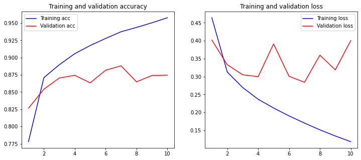

```python
tf.keras.backend.clear_session()
data_train,data_test,Max_Vocab_Size=cvtTexts2Sequences(train_x2_with_hashtags,test_x2_with_hashtags)
model2_tweets_with_hashtags=DeepLearingModelOnPostiveAndNegativeClasses(data_train,data_test,train_y2_with_hashtags,test_y2_with_hashtags,Max_Vocab_Size)
```

```python
model2_tweets_with_hashtags.save('/gdrive/MyDrive/Model2_tweets_with_hashtags.h5')
```

### let's try with tweets (2 classes) having split hashtags.

```
Found 50767 unique tokens.
Training Data shape: (26755, 60)
Testing Data shape: (6689, 60)
Model: "sequential"
_________________________________________________________________
Layer (type)                 Output Shape              Param #
=================================================================
embedding (Embedding)        (None, 60, 100)           5076800
_________________________________________________________________
bidirectional (Bidirectional (None, 60, 256)           234496
_________________________________________________________________
bidirectional_1 (Bidirection (None, 256)               394240
_________________________________________________________________
dropout (Dropout)            (None, 256)               0
_________________________________________________________________
dense (Dense)                (None, 1)                 257
=================================================================
Total params: 5,705,793
Trainable params: 5,705,793
Non-trainable params: 0
_________________________________________________________________
Training Accuracy: 0.9215
Training Loss: 0.2023
Testing Accuracy: 0.8743
Testing Loss:  0.3007
```

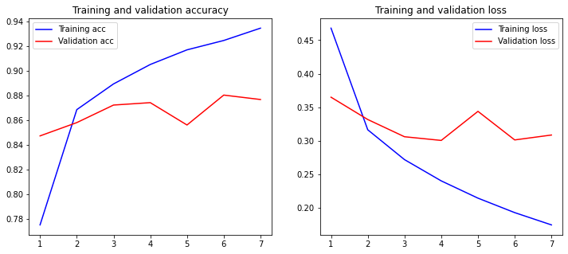

```python
tf.keras.backend.clear_session()
data_train,data_test,Max_Vocab_Size=cvtTexts2Sequences(train_x2_with_split_hashtags,test_x2_with_split_hashtags)
model2_tweets_with_split_hashtags=DeepLearingModelOnPostiveAndNegativeClasses(data_train,data_test, train_y2_with_split_hashtags,test_y2_with_split_hashtags,Max_Vocab_Size)
```

```python
model2_tweets_with_split_hashtags.save('/gdrive/MyDrive/Model2_tweets_with_split_hashtags.h5')
```

### let's try with tweets (2 classes) not having any hashtags.

```
Found 43092 unique tokens.
Training Data shape: (26755, 60)
Testing Data shape: (6689, 60)
Model: "sequential"
_________________________________________________________________
Layer (type)                 Output Shape              Param #
=================================================================
embedding (Embedding)        (None, 60, 100)           4309300
_________________________________________________________________
bidirectional (Bidirectional (None, 60, 256)           234496
_________________________________________________________________
bidirectional_1 (Bidirection (None, 256)               394240
_________________________________________________________________
dropout (Dropout)            (None, 256)               0
_________________________________________________________________
dense (Dense)                (None, 1)                 257
=================================================================
Total params: 4,938,293
Trainable params: 4,938,293
Non-trainable params: 0
_________________________________________________________________
Training Accuracy: 0.9440
Training Loss: 0.1483
Testing Accuracy: 0.8892
Testing Loss:  0.2761
```

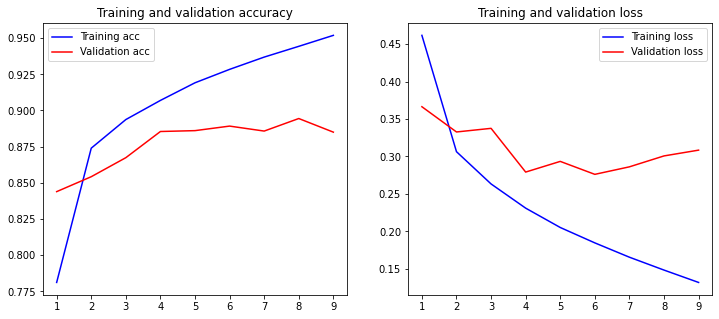

```python
tf.keras.backend.clear_session()
#train_x2_without_hashtags,train_y2_without_hashtags,test_x2_without_hashtags,test_y2_without_hashtags
data_train,data_test,Max_Vocab_Size=cvtTexts2Sequences(train_x2_without_hashtags,test_x2_without_hashtags)
model2_tweets_without_hashtags=DeepLearingModelOnPostiveAndNegativeClasses(data_train,data_test, train_y2_without_hashtags,test_y2_without_hashtags,Max_Vocab_Size)
```

```python
model2_tweets_without_hashtags.save('/gdrive/MyDrive/Model2_tweets_without_hashtags.h5')
```

### let's try with tweets (5 classes) having hashtags.

```
Found 57701 unique tokens.
Training Data shape: (32925, 60)
Testing Data shape: (8232, 60)
Model: "sequential"
_________________________________________________________________
Layer (type)                 Output Shape              Param #
=================================================================
embedding (Embedding)        (None, 60, 100)           5770200
_________________________________________________________________
bidirectional (Bidirectional (None, 60, 256)           234496
_________________________________________________________________
bidirectional_1 (Bidirection (None, 256)               394240
_________________________________________________________________
dropout (Dropout)            (None, 256)               0
_________________________________________________________________
dense (Dense)                (None, 5)                 1285
=================================================================
Total params: 6,400,221
Trainable params: 6,400,221
Non-trainable params: 0
_________________________________________________________________
Training Accuracy: 0.8356
Training Loss: 0.4930
Testing Accuracy: 0.7648
Testing Loss:  0.6973
```

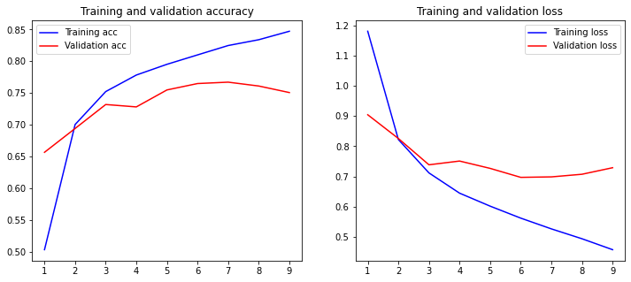

```python
tf.keras.backend.clear_session()
data_train,data_test,Max_Vocab_Size=cvtTexts2Sequences(train_x5_with_hashtags,test_x5_with_hashtags)
model5_tweet_with_hashtags=DeepLearingModelFor5Classes(data_train,data_test,train_y5_with_hashtags,test_y5_with_hashtags,Max_Vocab_Size)
```

```python
model5_tweet_with_hashtags.save('/gdrive/MyDrive/Model5_tweets_with_hashtags_.h5')
```

### let's try with tweets (5 classes) having split hashtags.

```
Found 57701 unique tokens.
Training Data shape: (32925, 60)
Testing Data shape: (8232, 60)
Model: "sequential"
_________________________________________________________________
Layer (type)                 Output Shape              Param #
=================================================================
embedding (Embedding)        (None, 60, 100)           5770200
_________________________________________________________________
bidirectional (Bidirectional (None, 60, 256)           234496
_________________________________________________________________
bidirectional_1 (Bidirection (None, 256)               394240
_________________________________________________________________
dropout (Dropout)            (None, 256)               0
_________________________________________________________________
dense (Dense)                (None, 5)                 1285
=================================================================
Total params: 6,400,221
Trainable params: 6,400,221
Non-trainable params: 0
_________________________________________________________________
Training Accuracy: 0.8352
Training Loss: 0.5014
Testing Accuracy: 0.7636
Testing Loss:  0.6879
```

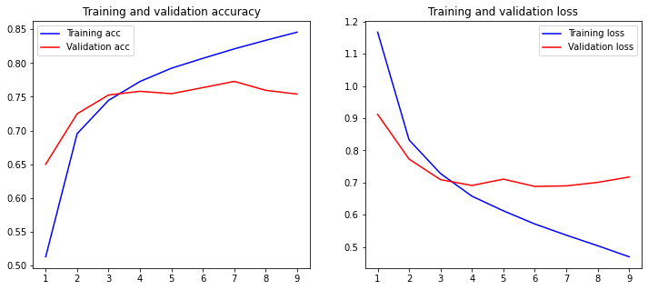

```python
tf.keras.backend.clear_session()
data_train,data_test,Max_Vocab_Size=cvtTexts2Sequences(train_x5_with_split_hashtags,test_x5_with_split_hashtags)
model5_tweets_with_split_hashtags=DeepLearingModelFor5Classes(data_train,data_test, train_y5_with_split_hashtags,test_y5_with_split_hashtags,Max_Vocab_Size)
```

```python
model5_tweets_with_split_hashtags.save('/gdrive/MyDrive/Model5_tweets_with_split_hashtags.h5')
```

### let's try with tweets (5 classes) not having any hashtags.

```
Found 48099 unique tokens.
Training Data shape: (32925, 60)
Testing Data shape: (8232, 60)
Model: "sequential"
_________________________________________________________________
Layer (type)                 Output Shape              Param #
=================================================================
embedding (Embedding)        (None, 60, 100)           4810000
_________________________________________________________________
bidirectional (Bidirectional (None, 60, 256)           234496
_________________________________________________________________
bidirectional_1 (Bidirection (None, 256)               394240
_________________________________________________________________
dropout (Dropout)            (None, 256)               0
_________________________________________________________________
dense (Dense)                (None, 5)                 1285
=================================================================
Total params: 5,440,021
Trainable params: 5,440,021
Non-trainable params: 0
_________________________________________________________________
Training Accuracy: 0.8500
Training Loss: 0.4576
Testing Accuracy: 0.7829
Testing Loss:  0.6207
```

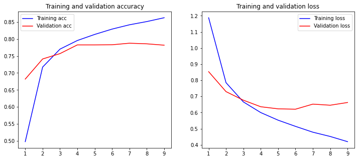

```python
tf.keras.backend.clear_session()
data_train,data_test,Max_Vocab_Size=cvtTexts2Sequences(train_x5_without_hashtags,test_x5_without_hashtags)
model5_tweets_without_hashtags=DeepLearingModelFor5Classes(data_train,data_test, train_y5_without_hashtags,test_y5_without_hashtags,Max_Vocab_Size)
```

```python
model5_tweets_without_hashtags.save('/gdrive/MyDrive/Model5_tweets_without_hashtags.h5')
```

# BOW Results On Postive And Negative Classes (2 classes)

### We train three different type of machine learing classifiers ( Logistic Regression - Naive Bayes - Linear Support Vector Machine ) on Tweets having postive and negative classes in many cases ( with hashtags - split hashtags- without hashtags ) using BOW method and the classifiers accuracy in the table below

```python
df_vis = pd.DataFrame({"BOW Method on tweets with hashtags":['98.24%','87.52%','90.18%','79.01%','99.90%','86.38%'],
                   "BOW Method on tweets with split hashtags":['98.22%','87.47%','90.14%','78.85%','99.90%','86.28%'] ,
                      "BOW Method on tweets without hashtags" : ['98.01%','88.26%','90.11%','79.80%','99.83%','87.73%']
                      })
df_vis.index = [
                'Logistic Regression on training data',
                'Logistic Regression on testing data',
                'Naive Bayes on training data',
                'Naive Bayes on testing data',
                'Linear Support Vector Machine on training data',
                'Linear Support Vector Machine on testing data'
               ]

df_vis
```

|  | BOW Method on tweets with hashtags | BOW Method on tweets with split hashtags | BOW Method on tweets without hashtags |
| --- | --- | --- | --- |
| Logistic Regression on training data | 98.24% | 98.22% | 98.01% |
| Logistic Regression on testing data | 87.52% | 87.47% | 88.26% |
| Naive Bayes on training data | 90.18% | 90.14% | 90.11% |
| Naive Bayes on testing data | 79.01% | 78.85% | 79.80% |
| Linear Support Vector Machine on training data | 99.90% | 99.90% | 99.83% |
| Linear Support Vector Machine on testing data | 86.38% | 86.28% | 87.73% |

# Tf-Idf Results On Postive And Negative Classes (2 classes)

### We train three different type of machine learing classifiers ( Logistic Regression - Naive Bayes - Linear Support Vector Machine ) on Tweets having postive and negative classes in many cases ( with hashtags - split hashtags- without hashtags ) using Tf-Idf method and the classifiers accuracy in the table below

```python
df_vis1 = pd.DataFrame({"Tf-Idf Method on tweets with hashtags":['91.25%','84.86%','86.21%','78.71%','97.50%','87.38%'],
                   "Tf-Idf Method on tweets with split hashtags":['91.28%','84.83%','86.24%','78.73%','97.54%','87.31%'] ,
                      "Tf-Idf Method on tweets without hashtags" : ['91.39%','85.75%','86.71%','79.95%','97.44%','88.16%']
                      })
df_vis1.index = [
                'Logistic Regression on training data',
                'Logistic Regression on testing data',
                'Naive Bayes on training data',
                'Naive Bayes on testing data',
                'Linear Support Vector Machine on training data',
                'Linear Support Vector Machine on testing data'
               ]

df_vis1
```

|  | Tf-Idf Method on tweets with hashtags | Tf-Idf Method on tweets with split hashtags | Tf-Idf Method on tweets without hashtags |
| --- | --- | --- | --- |
| Logistic Regression on training data | 91.25% | 91.28% | 91.39% |
| Logistic Regression on testing data | 84.86% | 84.83% | 85.75% |
| Naive Bayes on training data | 86.21% | 86.24% | 86.71% |
| Naive Bayes on testing data | 78.71% | 78.73% | 79.95% |
| Linear Support Vector Machine on training data | 97.50% | 97.54% | 97.44% |
| Linear Support Vector Machine on testing data | 87.38% | 87.31% | 88.16% |

# Deep Neural Networks

## 2 Classes Vs 5 Classes

### we have trained 6 deep learing models on tweets with 3 cases ( with hashtags - split hashtags- without hashtags ) and each three of them have the same structure

- the first three models for the 2 classes , each model of the three is for a certain tweet case
- the last three models for the 5 classes , each model of the three is for a certain tweet case

each model accuracy in the table blow

```python
df_vis2 = pd.DataFrame({"Tokenizer And Embedding Layer Method on tweets with hashtags":['95.30%','88.80%','83.56%','76.48%'],
                   "Tokenizer And Embedding Layer Method on tweets with split hashtags":['92.15%','87.43%','83.52%','76.36%'] ,
                      "Tokenizer And Embedding Layer Method on tweets without hashtags" : ['94.40%','88.92%','85.00%','78.29%']
                      })
df_vis2.index = [
                'Deep Learing Model On Postive And Negative Classes on training data',
                'Deep Learing Model On Postive And Negative Classes on testing data',
                'Deep Learing Model For 5 Classes on training data',
                'Deep Learing Model For 5 Classes on testing data'
               ]

df_vis2
```

|  | Tokenizer And Embedding Layer Method on tweets with hashtags | Tokenizer And Embedding Layer Method on tweets with split hashtags | Tokenizer And Embedding Layer Method on tweets without hashtags |
| --- | --- | --- | --- |
| Deep Learing Model On Postive And Negative Classes on training data | 95.30% | 92.15% | 94.40% |
| Deep Learing Model On Postive And Negative Classes on testing data | 88.80% | 87.43% | 88.92% |
| Deep Learing Model For 5 Classes on training data | 83.56% | 83.52% | 85.00% |
| Deep Learing Model For 5 Classes on testing data | 76.48% | 76.36% | 78.29% |

# Required Functions (cleaning_result && testing_result)

```python
def cleaning_result(list_of_strings):
    return [clean_Text_1(text) for text in list_of_strings]
```

```python
cleaning_result(["hello!! ?" , "hi! I am using whatsapp."])
```

```
['hello', 'hi i am using whatsapp']
```

```python
def testing_result(path):
    global df,df_binary_sentiment
    model2_tweets_without_hashtags = load_model("Model2_tweets_without_hashtags.h5")
    model5_tweets_without_hashtags = load_model("Model5_tweets_without_hashtags.h5")
    df1 = pd.read_csv(path,encoding="latin1")
    df1['OriginalTweet_without_hashtags'] = df1['OriginalTweet'].apply(lambda x: clean_Text_1(x,"removeHashtags"))
    df1['Sentiment2'] = df1['Sentiment'].apply(lambda x: cvt5CTo2C(x))
    df1['Sentiment5'] = df1['Sentiment'].apply(lambda x: cvt5CToNumerical5C(x))
    df_binary_sentiment1 = df1[ df1['Sentiment2'] != 2 ]

    MAX_VOCAB_SIZE = 5000

    tokenizer = Tokenizer(num_words=MAX_VOCAB_SIZE)
    tokenizer.fit_on_texts(df_binary_sentiment['OriginalTweet_without_hashtags'])
    sequences_train = tokenizer.texts_to_sequences(df_binary_sentiment['OriginalTweet_without_hashtags'])
    sequences_test = tokenizer.texts_to_sequences(df_binary_sentiment1['OriginalTweet_without_hashtags'])
    data_train = pad_sequences(sequences_train , padding='post')
    data_test = pad_sequences(sequences_test, padding='post' , maxlen=data_train.shape[1])

    loss2, accuracy2 = model2_tweets_without_hashtags.evaluate(data_test, df_binary_sentiment1['Sentiment2'] , verbose=False)
    print("Binary classification using Deep Neural Networks-- > Testing Accuracy : {:.4f}".format(accuracy2))

    print("\nML_Classifiers_using_bag_of_word on 2 classes")
    ML_Classifiers_using_bag_of_word(df_binary_sentiment['OriginalTweet_without_hashtags'], df_binary_sentiment['Sentiment2'] ,df_binary_sentiment1['OriginalTweet_without_hashtags'], df_binary_sentiment1['Sentiment2'] )
    print("\nML_Classifiers_using_tf_idf on 2 classes")
    ML_Classifiers_using_tf_idf(df_binary_sentiment['OriginalTweet_without_hashtags'], df_binary_sentiment['Sentiment2'] ,df_binary_sentiment1['OriginalTweet_without_hashtags'], df_binary_sentiment1['Sentiment2'] )

    tokenizer1 = Tokenizer(num_words=MAX_VOCAB_SIZE)
    tokenizer1.fit_on_texts(df['OriginalTweet_without_hashtags'])
    sequences_train = tokenizer1.texts_to_sequences(df['OriginalTweet_without_hashtags'])
    sequences_test = tokenizer1.texts_to_sequences(df1['OriginalTweet_without_hashtags'])
    data_train = pad_sequences(sequences_train , padding='post')
    data_test = pad_sequences(sequences_test, padding='post' , maxlen=data_train.shape[1])

    loss5, accuracy5 = model5_tweets_without_hashtags.evaluate(data_test, df['Sentiment5'] , verbose=False)
    print("Multiclass classification using Deep Neural Networks -- > Testing Accuracy : {:.4f}".format(accuracy5))
```